# SDS/CSC 293 Mini-Project 4: CART

Group 11: Nichole Yao and Starry Zhou

Wednesday, April 17<sup>th</sup>, 2019

You will be fitting CART models to the data from the [Ghouls, Goblins, and Ghosts… Boo!](https://www.kaggle.com/c/ghouls-goblins-and-ghosts-boo/) Kaggle competition. The competition’s score for leaderboard purposes is the “Categorization Accuracy”. However you will **NOT** be making any submissions to Kaggle.

# Load data

Read in data provided by Kaggle for this competition. They are organized in the `data/` folder of this RStudio project:

```r
training <- read_csv("data/train.csv")
test <- read_csv("data/test.csv")
sample_submission <- read_csv("data/sample_submission.csv")

training<- training%>%
  mutate(type=as.factor(type))
```

## Look at your data!

Always, ALWAYS, **ALWAYS** start by looking at your raw data. This gives you visual sense of what information you have to help build your predictive models. To get a full description of each variable, read the data dictionary in the `data_description.txt` file in the `data/` folder.

Note that the following code chunk has `eval = FALSE` meaning “don’t evaluate this chunk with knitting” because `.Rmd` files won’t knit if they include a `View()`:

```r
View(training)
glimpse(training)

View(test)
glimpse(test)
```

In particular, pay close attention to the variables and variable types in the `sample_submission.csv`. Your submission must match this exactly.

```r
glimpse(sample_submission)
```

```
## Observations: 529
## Variables: 2
## $ id   <int> 3, 6, 9, 10, 13, 14, 15, 16, 17, 18, 20, 21, 24, 26, 33, 38…
## $ type <chr> "Ghost", "Ghost", "Ghost", "Ghost", "Ghost", "Ghost", "Ghos…
```

# Minimally viable product

Perform the following exploratory data analyses:

## Univariate explorations

**Categorical predictor**: Create a visualization of the categorical predictor variable `color`.

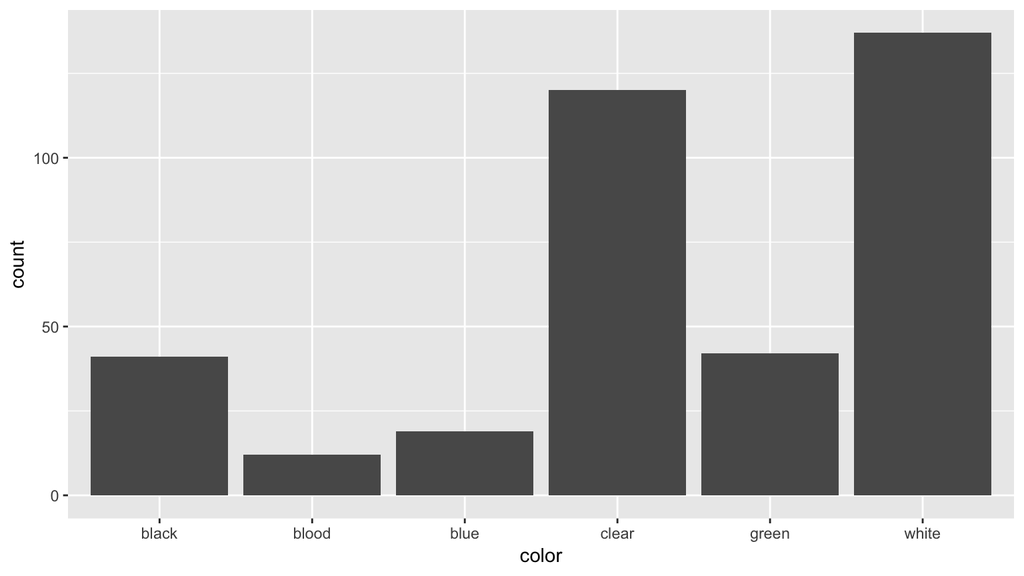

```r
ggplot(data = training, aes(x=color))+
  geom_bar()
```

**Outcome variable**: Create a visualization of the categorical predictor variable `type`.

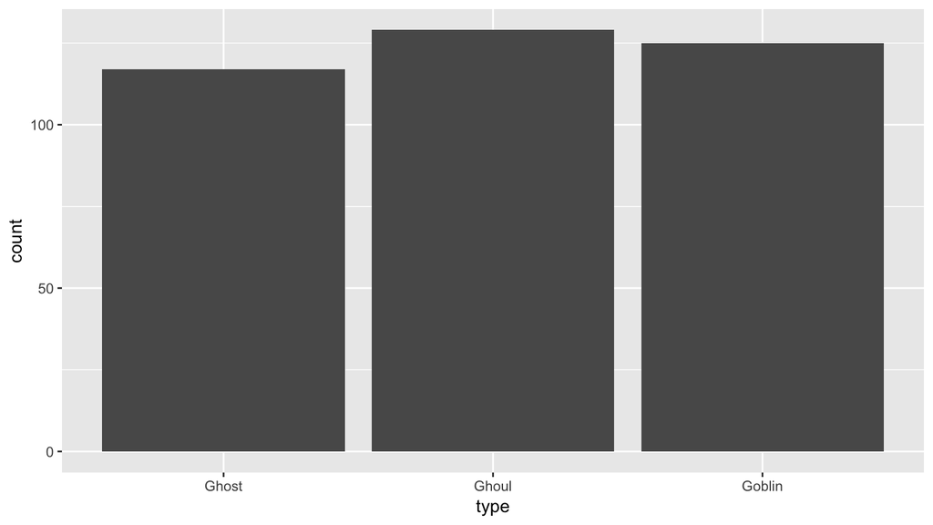

```r
ggplot(data = training, aes(x=type))+
  geom_bar()
```

## Mutlivariate explorations

**Numerical predictors**: Create a visualization of the relationship of all four numerical predictor variables at once (`bone_length`, `rotting_flesh`, `hair_length`, `has_soul`) using the `ggpairs()` function from the `GGally` [package](http://ggobi.github.io/ggally/#ggallyggpairs).

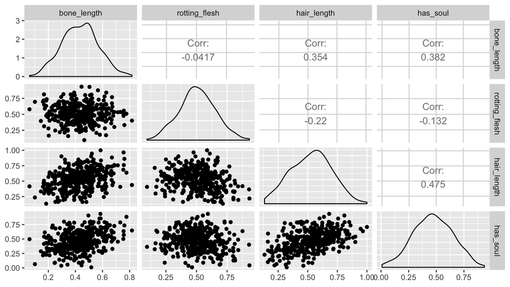

```r
ggpairs(training, columns = c("bone_length", "rotting_flesh", "hair_length", "has_soul"))
```

**Relationship of categorical predictor and outcome variable**: Create a visualization of the relationship between the categorical outcome variable `type` and any predictor varible of your choosing.

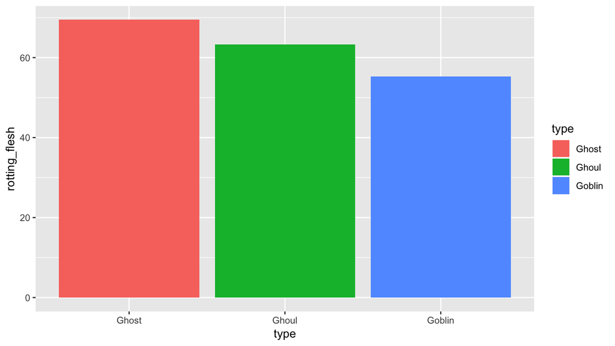

```r
ggplot(data=training, aes(x=type,y=rotting_flesh,fill=type))+
  geom_bar(stat="identity")
```

# Due diligence

1. Fit a CART where:
   - You use only the numerical predictors.
   - The maximum depth of the tree is 5.
   - You use the default “complexity parameter”
2. Plot the tree.
3. Make predictions `type_hat` on the `training` data. Hint compare the output of `predict(model_CART, type = "prob")` and `predict(model_CART, type = "class")`.
4. Compute the “classification accuracy”.

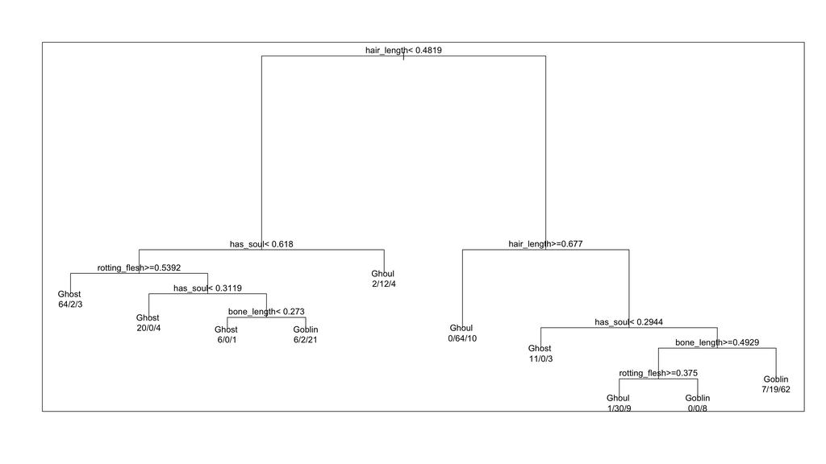

```r
model_formula <- as.formula(type ~ bone_length+rotting_flesh+hair_length+has_soul)
tree_parameters <- rpart.control(maxdepth = 5)
model_CART <- rpart(model_formula, data = training, control = tree_parameters)

plot(model_CART)
text(model_CART, use.n = TRUE)
box()
```

```r
p_hat_matrix_test <- model_CART %>%
  predict(type = "prob", newdata = training) %>%
  as_tibble()

model_1_fitted_points<-model_CART %>%
  predict(type="class", newdata = training) %>%
  enframe()

accuracy(data=training, truth=factor(type),estimate= factor(model_1_fitted_points$value))
```

| .metric | .estimator | .estimate |
| --- | --- | --- |
| accuracy | multiclass | 0.8032345 |